# RSi_Coding_Challenge_Football-Results_part2

```python
import numpy as np
import pandas as pd
import seaborn as sns
import matplotlib.pyplot as plt
import warnings
warnings.filterwarnings(action = 'ignore')
```

```python
df = pd.read_csv('results.csv')
```

```python
df_original = df
```

```python
df.head()
```

|  | date | home_team | away_team | home_score | away_score | tournament | city | country | neutral |
| --- | --- | --- | --- | --- | --- | --- | --- | --- | --- |
| 0 | 1872-11-30 | Scotland | England | 0 | 0 | Friendly | Glasgow | Scotland | False |
| 1 | 1873-03-08 | England | Scotland | 4 | 2 | Friendly | London | England | False |
| 2 | 1874-03-07 | Scotland | England | 2 | 1 | Friendly | Glasgow | Scotland | False |
| 3 | 1875-03-06 | England | Scotland | 2 | 2 | Friendly | London | England | False |
| 4 | 1876-03-04 | Scotland | England | 3 | 0 | Friendly | Glasgow | Scotland | False |

```python
df.shape
```

```
(40839, 9)
```

**Observation**

1. **Data set contains 40839 rows and 9 columns.**

```python
df.columns
```

```
Index(['date', 'home_team', 'away_team', 'home_score', 'away_score',
       'tournament', 'city', 'country', 'neutral'],
      dtype='object')
```

### Check for missig values across features

```python
df.isnull().sum()/len(df)
```

```
date          0.0
home_team     0.0
away_team     0.0
home_score    0.0
away_score    0.0
tournament    0.0
city          0.0
country       0.0
neutral       0.0
dtype: float64
```

**Observation :**

1. **None of the features have missing values present.**

### Analyzing numeric features

```python
df.describe()
```

|  | home_score | away_score |
| --- | --- | --- |
| count | 40839.000000 | 40839.000000 |
| mean | 1.745709 | 1.188105 |
| std | 1.749145 | 1.405120 |
| min | 0.000000 | 0.000000 |
| 25% | 1.000000 | 0.000000 |
| 50% | 1.000000 | 1.000000 |
| 75% | 2.000000 | 2.000000 |
| max | 31.000000 | 21.000000 |

**Observations :**

1. **In general, from the distribution of the mean and std deviation for the home_score and away_score, it can be infered that the home teams have scored higher no. of goals compared to away teams on an average. So winning percentage of home teams looks greater compared to the away teams.**
2. **With max score of 31 and 21 for the home and away teams resp, there is prsence of outliers in the data.**
3. **Also 50% of the distribution (i.e. between quartiles values of 25% to 75%) for the home_score and away_score lies between 0 to 2 goals.**

### Analyzing non-numeric (categorical) features

```python
df.describe(exclude= np.number)
```

|  | date | home_team | away_team | tournament | city | country | neutral |
| --- | --- | --- | --- | --- | --- | --- | --- |
| count | 40839 | 40839 | 40839 | 40839 | 40839 | 40839 | 40839 |
| unique | 15115 | 309 | 306 | 109 | 1960 | 266 | 2 |
| top | 2012-02-29 | Brazil | Uruguay | Friendly | Kuala Lumpur | United States | False |
| freq | 66 | 563 | 536 | 16911 | 581 | 1144 | 30680 |

**Observations :**

### Neutral feature data disparity/mismatch

```python
df[(df['home_team'] == df['country']) & (df['neutral'] == True)]
```

|  | date | home_team | away_team | home_score | away_score | tournament | city | country | neutral |
| --- | --- | --- | --- | --- | --- | --- | --- | --- | --- |
| 10930 | 1979-08-29 | Fiji | Papua New Guinea | 0 | 0 | South Pacific Games | Suva | Fiji | True |
| 35287 | 2013-07-15 | Bermuda | Falkland Islands | 8 | 0 | Island Games | Hamilton | Bermuda | True |
| 40602 | 2019-06-07 | China PR | Philippines | 2 | 0 | Friendly | Guangzhou | China PR | True |

**Observation :**

1. **Disparity is present across the data in the dataset for the above 3 home_teams which have played in own country but the venue is still marked as neutral for these.**

### Teams who have not played matches on neutral venue

```python
teamshm = ''
for a in df['home_team'].to_list():
    if a not in df['away_team'].to_list():
        teamshm += "'" + a + "', "
        continue
teamshm
```

```
"'Silesia', 'Silesia', 'Silesia', 'Silesia', 'Silesia', 'Silesia', 'Silesia', 'Niue', 'Niue', 'Palau', 'Canary Islands', 'Palau', 'Canary Islands', 'Canary Islands', 'Republic of St. Pauli', 'Republic of St. Pauli', 'Republic of St. Pauli', 'Republic of St. Pauli', 'Găgăuzia', 'Găgăuzia', 'Găgăuzia'…
```

```python
df[(df['away_team'] == 'Madrid') & (df['neutral'] == True)]
```

|  | date | home_team | away_team | home_score | away_score | tournament | city | country | neutral |
| --- | --- | --- | --- | --- | --- | --- | --- | --- | --- |

Below are the teams who have not played matches on Neutral venue: Silesia Niue Palau Canary Islands Republic of St. Pauli Găgăuzia Madrid

### Teams who have not played matches on home venue

```python
teamsaw = ''
for a in df['away_team'].to_list():
    if a not in df['home_team'].to_list():
        teamsaw += "'" + a + "', "
        continue
teamsaw
```

```
"'Asturias', 'Western Australia', 'Western Australia', 'Western Australia', 'Western Australia', 'Western Australia', 'Western Australia', 'Western Australia', 'Western Australia', 'Western Australia', 'Western Australia', 'Western Australia', 'Western Australia', 'Western Australia', 'Western Austr…
```

```python
df[df['country']=='Western Australia']
```

|  | date | home_team | away_team | home_score | away_score | tournament | city | country | neutral |
| --- | --- | --- | --- | --- | --- | --- | --- | --- | --- |

```python
df[(df['home_team']=='Western Australia') & (df['country']=='Western Australia') & (df['neutral'] == False)]
```

|  | date | home_team | away_team | home_score | away_score | tournament | city | country | neutral |
| --- | --- | --- | --- | --- | --- | --- | --- | --- | --- |

Below are the teams who have not played matches on home venue as home venue does not exist for them: Asturias Western Australia Two Sicilies Surrey

### Teams for which the country name and home_team name are different but are actually the same nation teams

```python
df[(df['home_team'] != df['country']) & (df['neutral'] == False)][['home_team','away_team','country','neutral']]
```

|  | home_team | away_team | country | neutral |
| --- | --- | --- | --- | --- |
| 19 | Northern Ireland | England | Republic of Ireland | False |
| 28 | Northern Ireland | Wales | Republic of Ireland | False |
| 29 | Northern Ireland | Scotland | Republic of Ireland | False |
| 31 | Northern Ireland | England | Republic of Ireland | False |
| 40 | Northern Ireland | Wales | Republic of Ireland | False |
| ... | ... | ... | ... | ... |
| 40688 | Ynys Môn | Western Isles | Wales | False |
| 40695 | Ynys Môn | Orkney | Wales | False |
| 40702 | Ynys Môn | Jersey | Wales | False |
| 40717 | Ynys Môn | Shetland | Wales | False |
| 40723 | Ynys Môn | Guernsey | Wales | False |

745 rows × 4 columns

# Feature Engineering - Adding New Features

```python
df['home_won'] = [1 if i>j else 0 for i,j in zip(df.home_score,df.away_score)]
df['away_won'] = [1 if i<j else 0 for i,j in zip(df.home_score,df.away_score)]
df['drawn'] = [1 if i==j else 0 for i,j in zip(df.home_score,df.away_score)]
df['year'] = df['date'].apply(lambda x : x[0:4]).astype(int)
```

```python
df['winning_team'] = np.where((df['home_won'] == 1), df['home_team'], df['away_team'])
df['winning_team'] = np.where((df['drawn'] == 1), 'NoResult', df['winning_team'])
```

```python
df.head(3)
```

|  | date | home_team | away_team | home_score | away_score | tournament | city | country | neutral | home_won | away_won | drawn | year | winning_team |
| --- | --- | --- | --- | --- | --- | --- | --- | --- | --- | --- | --- | --- | --- | --- |
| 0 | 1872-11-30 | Scotland | England | 0 | 0 | Friendly | Glasgow | Scotland | False | 0 | 0 | 1 | 1872 | NoResult |
| 1 | 1873-03-08 | England | Scotland | 4 | 2 | Friendly | London | England | False | 1 | 0 | 0 | 1873 | England |
| 2 | 1874-03-07 | Scotland | England | 2 | 1 | Friendly | Glasgow | Scotland | False | 1 | 0 | 0 | 1874 | Scotland |

# Exploratory Data Analysis (EDA)

```python
df.dtypes
```

```
date            object
home_team       object
away_team       object
home_score       int64
away_score       int64
tournament      object
city            object
country         object
neutral           bool
home_won         int64
away_won         int64
drawn            int64
year             int32
winning_team    object
dtype: object
```

**Observations :**

1. **'home_score' and 'away_score' are integer features which describes the goals scored by home and away team resp.**
2. **Except the 'date' feature, which reprents the date of the match, the rest of the object types features are categorical features like 'home_team', 'away_team','tournament', 'city', 'country'.**
3. **'home_team' and 'country' features have the same values except for some observations where it is different becuase the the name of country was different at the time, the match was played. But such records are taken care of by setting the neutral feature to 'False'.**
4. **'neutral' is a boolean feature which describes the type of venue for the match, i.e. whether it is a home venue for the home team or not. If home venue, the value is 'False' otherwise 'True'.**

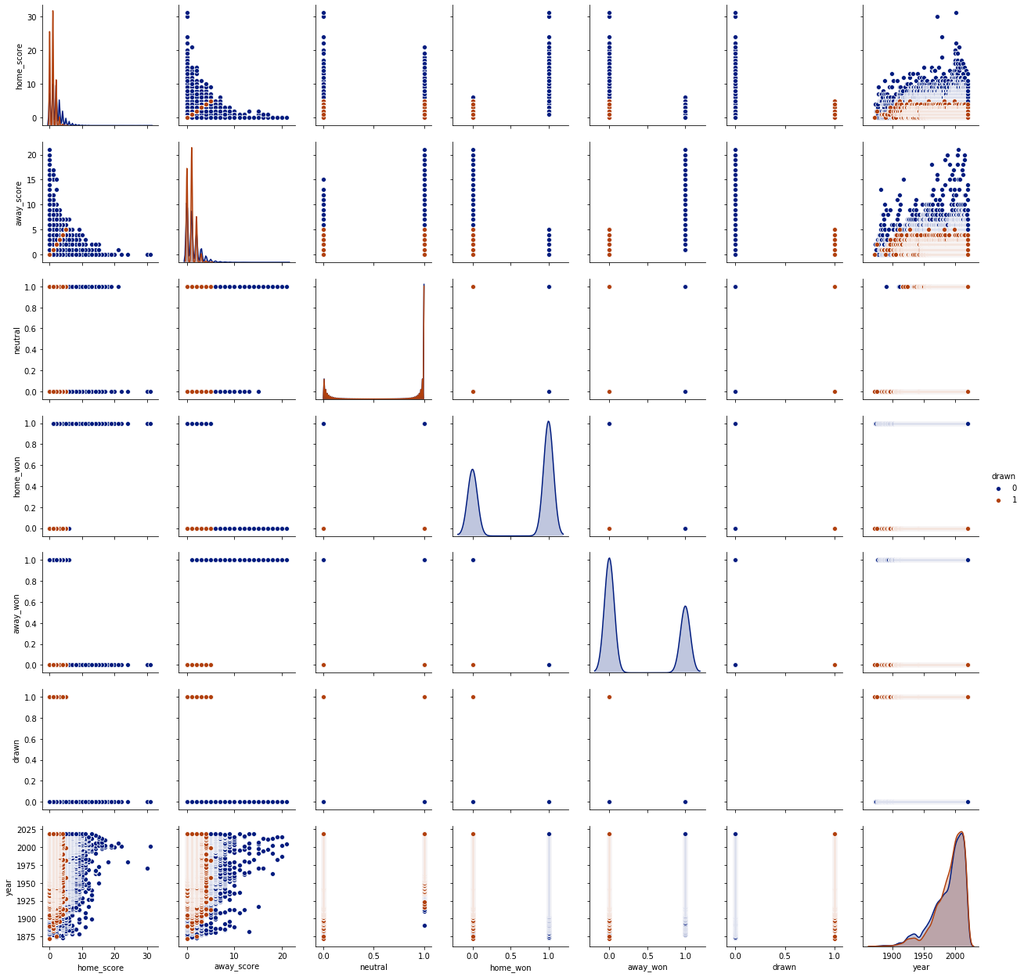

```python
sns.pairplot(df,hue='drawn',palette = 'dark')
```

**Observations :**

- **Fromt the distribution,it can be infered that, the away team has less winning ration compared to home team.**

### winning_team

```python
df['winning_team'].value_counts(normalize=True).head(10)#.plot.bar(figsize=(12,5))
```

```
NoResult       0.230931
Brazil         0.015304
England        0.013786
Germany        0.013492
Argentina      0.012831
Sweden         0.012096
South Korea    0.010994
Mexico         0.010603
Hungary        0.010603
Italy          0.010235
Name: winning_team, dtype: float64
```

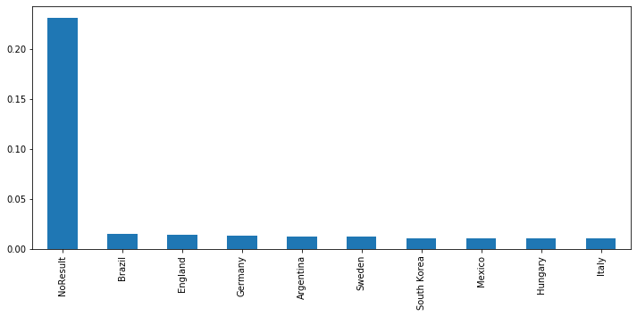

```python
df['winning_team'].value_counts(normalize=True).head(10).plot.bar(figsize=(12,5))
```

**Observation:**

- **To many matches ended up in drawn and hence had no results.**
- **Brazil has the highest percentage of winning the matches.**

### home_score

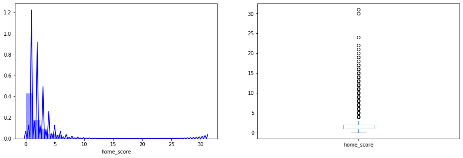

```python
plt.figure(1,figsize=(16,5))
plt.subplot(121)
sns.distplot(df['home_score'],bins=25,color='b')

plt.subplot(122)
df['home_score'].plot.box()
plt.show()
```

**Observations :**

- **The distribution of home_score is right skewed which means it is not normally distributed. We will try to make it normal later as algorithms works better if the data is normally distributed.**
- **The boxplot confirms the presence of a lot of outliers/extreme values. This is due to the fact that the home team has a higher winning percentage compared to away_team.**

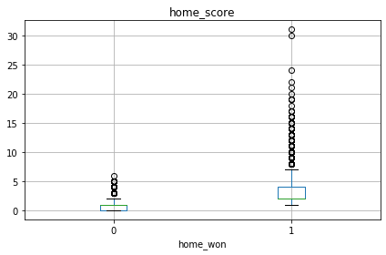

```python
# home_score BoxPlot group by home_won

df.boxplot(column='home_score', by = 'home_won')
plt.suptitle('')
plt.tight_layout()
```

**The home team tend to score more goals and thus there are higher number of home wins which are appearing to be the outliers.**

### away_score

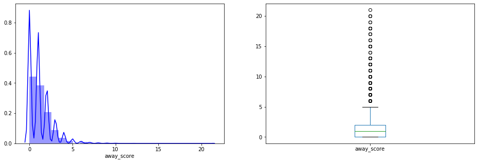

```python
plt.figure(1,figsize=(16,5))
plt.subplot(121)
sns.distplot(df['away_score'],bins=25,color='b')

plt.subplot(122)
df['away_score'].plot.box()
plt.show()
```

**Observations :**

- **The distribution of away_score is right skewed which means it is not normally distributed. We will try to make it normal later as algorithms works better if the data is normally distributed.**
- **The boxplot confirms the presence of a lot of outliers/extreme values.**

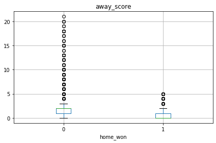

```python
# away_score BoxPlot group by home_won

df.boxplot(column='away_score', by = 'home_won')
plt.suptitle('')
plt.tight_layout()
```

**The away team tend to score less goals and thus there are higher number of home wins which are appearing to be the outliers for away_score.**

### neutral

```python
df['neutral'].value_counts(normalize=True)
```

```
False    0.751243
True     0.248757
Name: neutral, dtype: float64
```

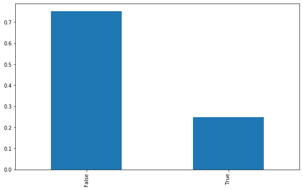

```python
df['neutral'].value_counts(normalize=True).plot.bar(figsize=(10,6))
```

**Observations :**

- **Almost 25% of the matches were played on the neutral venues.**

### home_won

```python
df['home_won'].value_counts(normalize=True)
```

```
0    0.513602
1    0.486398
Name: home_won, dtype: float64
```

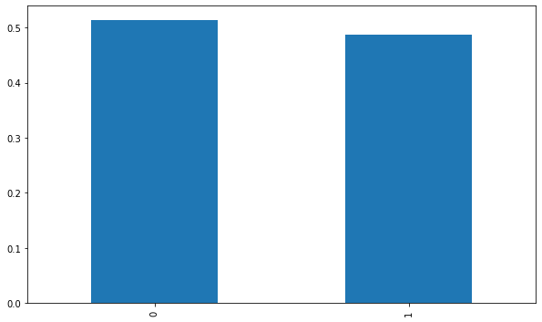

```python
df['home_won'].value_counts(normalize=True).plot.bar(figsize=(10,6))
```

**Observations :**

- **The distribution of home_won is almost balance with home team winning around 49% of the matches played at home.**

### away_won

```python
df['away_won'].value_counts(normalize=True)
```

```
0    0.717329
1    0.282671
Name: away_won, dtype: float64
```

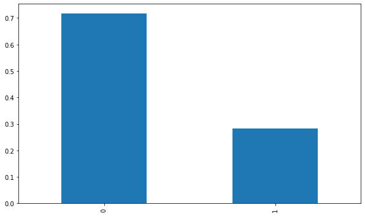

```python
df['away_won'].value_counts(normalize=True).plot.bar(figsize=(10,6))
```

**Observations :**

### drawn

```python
df['drawn'].value_counts(normalize=True)
```

```
0    0.769069
1    0.230931
Name: drawn, dtype: float64
```

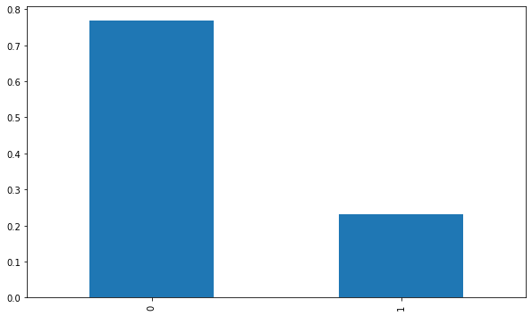

```python
df['drawn'].value_counts(normalize=True).plot.bar(figsize=(10,6))
```

**Observations :**

- **Around 23% of the total matches played were resulted in draw(NoResult).**

### home_team - away_team - country - winning_team

```python
df_wt = df.loc[(df['neutral']==False),['home_team','away_team','country','home_score','away_score','home_won','away_won','drawn','winning_team']]
df_wt
```

|  | home_team | away_team | country | home_score | away_score | home_won | away_won | drawn | winning_team |
| --- | --- | --- | --- | --- | --- | --- | --- | --- | --- |
| 0 | Scotland | England | Scotland | 0 | 0 | 0 | 0 | 1 | NoResult |
| 1 | England | Scotland | England | 4 | 2 | 1 | 0 | 0 | England |
| 2 | Scotland | England | Scotland | 2 | 1 | 1 | 0 | 0 | Scotland |
| 3 | England | Scotland | England | 2 | 2 | 0 | 0 | 1 | NoResult |
| 4 | Scotland | England | Scotland | 3 | 0 | 1 | 0 | 0 | Scotland |
| ... | ... | ... | ... | ... | ... | ... | ... | ... | ... |
| 40803 | Samoa | Papua New Guinea | Samoa | 0 | 6 | 0 | 1 | 0 | Papua New Guinea |
| 40817 | Samoa | Tonga | Samoa | 2 | 0 | 1 | 0 | 0 | Samoa |
| 40821 | India | North Korea | India | 2 | 5 | 0 | 1 | 0 | North Korea |
| 40829 | India | Syria | India | 1 | 1 | 0 | 0 | 1 | NoResult |
| 40832 | Samoa | Vanuatu | Samoa | 0 | 11 | 0 | 1 | 0 | Vanuatu |

30680 rows × 9 columns

**Observations:**

1. **A total of 30680 matches were played on the home venue.**

```python
df_hwt = df_wt[(df_wt['home_team'] == df_wt['winning_team']) & (df_wt['drawn'] == 0)][['home_team','country','winning_team']]
df_hwt
```

|  | home_team | country | winning_team |
| --- | --- | --- | --- |
| 1 | England | England | England |
| 2 | Scotland | Scotland | Scotland |
| 4 | Scotland | Scotland | Scotland |
| 5 | Scotland | Scotland | Scotland |
| 8 | Scotland | Scotland | Scotland |
| ... | ... | ... | ... |
| 40778 | United States | United States | United States |
| 40787 | Brazil | Brazil | Brazil |
| 40790 | United States | United States | United States |
| 40798 | Brazil | Brazil | Brazil |
| 40817 | Samoa | Samoa | Samoa |

15481 rows × 3 columns

**Observations:**

1. **A total of 15481 matches were won by the home team who played on the home venue.**

```python
df_hwt.shape[0]/df_wt.shape[0]
```

```
0.5045958279009126
```

**Observations:**

### home_team vs home_won

```python
home_won=pd.crosstab(index=df['home_team'],columns=df['home_won'])
home_won = home_won.sort_values('home_team',ascending=True)
home_won
```

| home_won home_team | 0 | 1 |
| --- | --- | --- |
| Abkhazia | 9 | 9 |
| Afghanistan | 21 | 16 |
| Albania | 111 | 61 |
| Alderney | 7 | 0 |
| Algeria | 129 | 157 |
| ... | ... | ... |
| Yugoslavia | 82 | 108 |
| Zambia | 133 | 164 |
| Zanzibar | 41 | 17 |
| Zimbabwe | 89 | 97 |
| Åland Islands | 13 | 14 |

309 rows × 2 columns

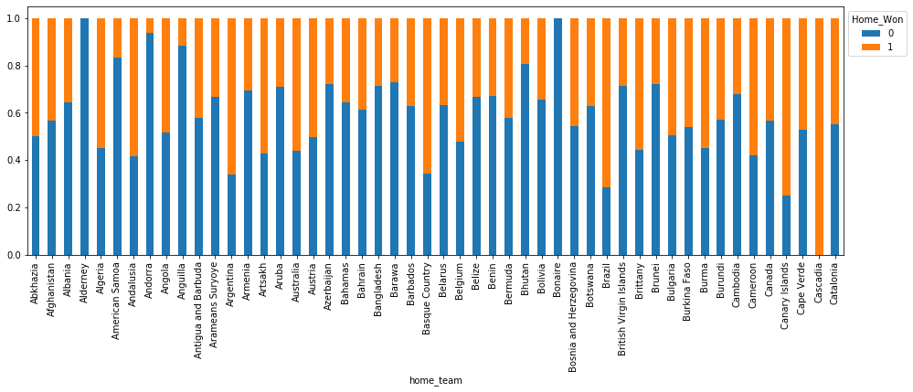

```python
home_won.head(50).div(home_won.head(50).sum(1).astype(float), axis=0).plot(kind="bar", stacked=True, figsize=(16,5))
plt.legend(loc = 'upper left',bbox_to_anchor= (1,1),title='Home_Won')
plt.show()
```

**Observations :**

- **Almost 50% of the home_teams have won the matches at home venue.**

### away_team vs away_won

```python
away_won=pd.crosstab(index=df['away_team'],columns=df['away_won'])
away_won = away_won.sort_values('away_team',ascending=True)
away_won
```

| away_won away_team | 0 | 1 |
| --- | --- | --- |
| Abkhazia | 7 | 3 |
| Afghanistan | 56 | 13 |
| Albania | 133 | 21 |
| Alderney | 9 | 3 |
| Algeria | 159 | 52 |
| ... | ... | ... |
| Yugoslavia | 175 | 115 |
| Zambia | 250 | 160 |
| Zanzibar | 123 | 24 |
| Zimbabwe | 174 | 87 |
| Åland Islands | 12 | 7 |

306 rows × 2 columns

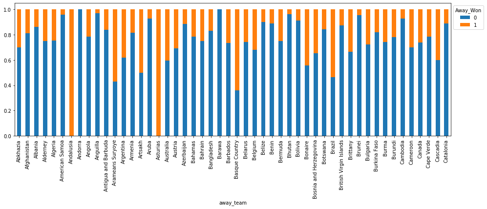

```python
away_won.head(50).div(away_won.head(50).sum(1).astype(float), axis=0).plot(kind="bar", stacked=True, figsize=(16,5))
plt.legend(loc = 'upper left',bbox_to_anchor= (1,1),title='Away_Won')
plt.show()
```

**Observations :**

### tournament

```python
df['tournament'].value_counts(normalize=True)
```

```
Friendly                                0.414089
FIFA World Cup qualification            0.173853
UEFA Euro qualification                 0.059551
African Cup of Nations qualification    0.039570
FIFA World Cup                          0.022038
                                          ...
Dragon Cup                              0.000098
World Unity Cup                         0.000098
Copa América qualification              0.000049
Atlantic Heritage Cup                   0.000049
AFF Championship qualification          0.000049
Name: tournament, Length: 109, dtype: float64
```

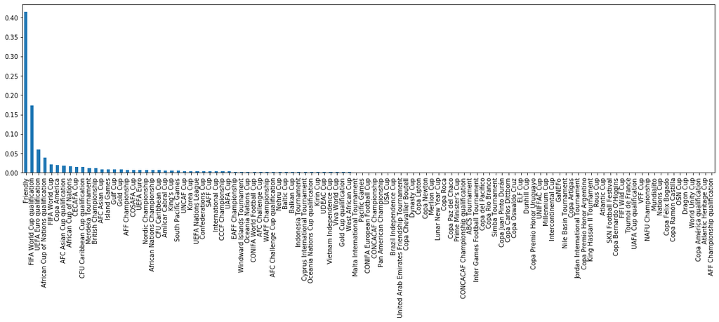

```python
df['tournament'].value_counts(normalize = True).plot.bar(figsize=(20,5))
```

**Observations**

### Top 10 tournaments

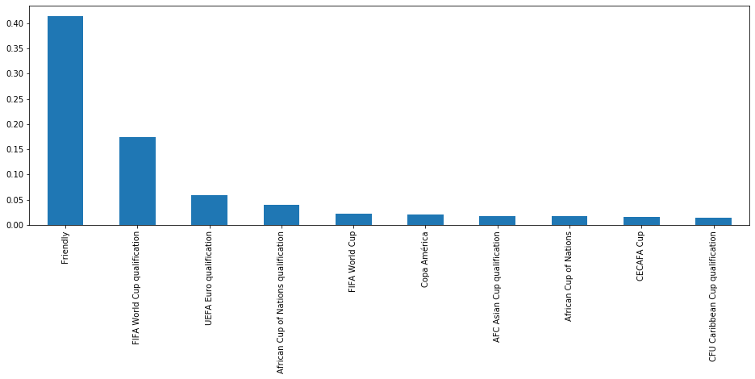

```python
df['tournament'].value_counts(normalize = True).head(10).plot.bar(figsize=(16,5))
```

```python
dft = df.loc[(df['tournament'] == 'Friendly'),['home_team','away_team','tournament','winning_team']]
dft
```

|  | home_team | away_team | tournament | winning_team |
| --- | --- | --- | --- | --- |
| 0 | Scotland | England | Friendly | NoResult |
| 1 | England | Scotland | Friendly | England |
| 2 | Scotland | England | Friendly | Scotland |
| 3 | England | Scotland | Friendly | NoResult |
| 4 | Scotland | England | Friendly | Scotland |
| ... | ... | ... | ... | ... |
| 40677 | Morocco | Gambia | Friendly | Gambia |
| 40678 | Ynys Môn | Saint Helena | Friendly | Ynys Môn |
| 40679 | Egypt | Tanzania | Friendly | Egypt |
| 40680 | Cameroon | Mali | Friendly | NoResult |
| 40681 | Madagascar | Mauritania | Friendly | Mauritania |

16911 rows × 4 columns

```python
all_friedly_teams = dft['home_team'].to_list() + dft['away_team'].to_list()
all_friedly_teams =  pd.Series(all_friedly_teams)
```

```python
all_friedly_teams = all_friedly_teams.value_counts().reset_index().rename(columns={0:'no_of_friendly_tornaments','index':'all_teams'})
```

```python
most_active_friendly = all_friedly_teams.head(12)
most_active_friendly
```

|  | all_teams | no_of_friendly_tornaments |
| --- | --- | --- |
| 0 | Germany | 567 |
| 1 | Hungary | 557 |
| 2 | Sweden | 538 |
| 3 | Poland | 526 |
| 4 | France | 486 |
| 5 | Switzerland | 454 |
| 6 | Austria | 453 |
| 7 | Netherlands | 449 |
| 8 | Belgium | 444 |
| 9 | Mexico | 432 |
| 10 | Brazil | 428 |
| 11 | England | 408 |

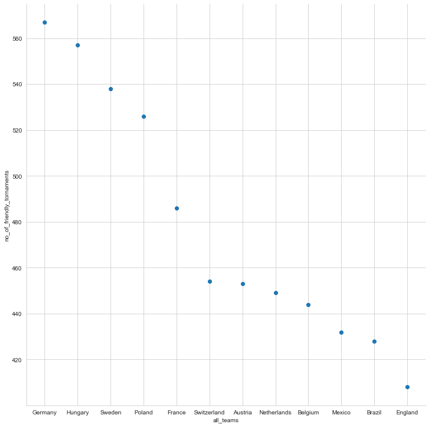

```python
sns.set_style("whitegrid");
sns.FacetGrid(most_active_friendly, size=(10)) \
   .map(plt.scatter, "all_teams", "no_of_friendly_tornaments") \
   .add_legend();
plt.show();
```

**Observation:**

- **'Germany','Hungary','Sweden','Poland','France','Switzerland','Austria','Netherlands','Belgium','Mexico','Brazil','England' are the most active in playing Friendly tournaments**

### convert the variable’s ('neutral') into 0 and 1 so that we can find its correlation with numerical variables.

```python
df.neutral.replace(False,0,inplace=True)
df.neutral.replace(True,1,inplace=True)
```

### Correlation between all the Numeric variables

- Heatmap is used to visualize the correlation.

```python
df.corr()
```

|  | home_score | away_score | neutral | home_won | away_won | drawn | year |
| --- | --- | --- | --- | --- | --- | --- | --- |
| home_score | 1.000000 | -0.133412 | -0.031660 | 0.602645 | -0.421703 | -0.264146 | -0.123567 |
| away_score | -0.133412 | 1.000000 | 0.084335 | -0.465938 | 0.621396 | -0.111361 | -0.133891 |
| neutral | -0.031660 | 0.084335 | 1.000000 | -0.063273 | 0.073757 | -0.003767 | 0.107900 |
| home_won | 0.602645 | -0.465938 | -0.063273 | 1.000000 | -0.610891 | -0.533263 | -0.013318 |
| away_won | -0.421703 | 0.621396 | 0.073757 | -0.610891 | 1.000000 | -0.343986 | -0.025401 |
| drawn | -0.264146 | -0.111361 | -0.003767 | -0.533263 | -0.343986 | 1.000000 | 0.042936 |
| year | -0.123567 | -0.133891 | 0.107900 | -0.013318 | -0.025401 | 0.042936 | 1.000000 |

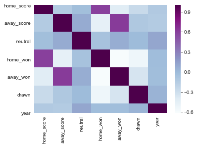

```python
sns.heatmap(data=df.corr(),square=False, cmap='BuPu')
```

**Observations :**

- **It can be infered that the most correlated variables are (home_score - home_won) and (away_score - away_won).**

```python
df.columns
```

```
Index(['date', 'home_team', 'away_team', 'home_score', 'away_score',
       'tournament', 'city', 'country', 'neutral', 'home_won', 'away_won',
       'drawn', 'year', 'winning_team'],
      dtype='object')
```

# MODEL BUILDING

### Encoding the categorial features

```python
df.describe(include=[pd.Categorical])
```

|  | date | home_team | away_team | tournament | city | country | winning_team |
| --- | --- | --- | --- | --- | --- | --- | --- |
| count | 40839 | 40839 | 40839 | 40839 | 40839 | 40839 | 40839 |
| unique | 15115 | 309 | 306 | 109 | 1960 | 266 | 302 |
| top | 2012-02-29 | Brazil | Uruguay | Friendly | Kuala Lumpur | United States | NoResult |
| freq | 66 | 563 | 536 | 16911 | 581 | 1144 | 9431 |

```python
from sklearn.preprocessing import LabelEncoder
lbl_enc = LabelEncoder()
```

```python
df['home_team_enc'] = lbl_enc.fit_transform(df['home_team'])
df['away_team_enc'] = lbl_enc.fit_transform(df['away_team'])
df['tournament_enc'] = lbl_enc.fit_transform(df['tournament'])
df['city_enc'] = lbl_enc.fit_transform(df['city'])
df['country_enc'] = lbl_enc.fit_transform(df['country'])
df['winning_team_enc'] = lbl_enc.fit_transform(df['winning_team'])
```

```python
#df = df.drop(labels=['home_team', 'away_team', 'tournament', 'city', 'country', 'winning_team'],axis=1)
df.columns
```

```
Index(['date', 'home_team', 'away_team', 'home_score', 'away_score',
       'tournament', 'city', 'country', 'neutral', 'home_won', 'away_won',
       'drawn', 'year', 'winning_team', 'home_team_enc', 'away_team_enc',
       'tournament_enc', 'city_enc', 'country_enc', 'winning_team_enc'],
      dtype='object')
```

```python
df.head()
```

|  | date | home_team | away_team | home_score | away_score | tournament | city | country | neutral | home_won | away_won | drawn | year | winning_team | home_team_enc | away_team_enc | tournament_enc | city_enc | country_enc | winning_team_enc |
| --- | --- | --- | --- | --- | --- | --- | --- | --- | --- | --- | --- | --- | --- | --- | --- | --- | --- | --- | --- | --- |
| 0 | 1872-11-30 | Scotland | England | 0 | 0 | Friendly | Glasgow | Scotland | 0.0 | 0 | 0 | 1 | 1872 | NoResult | 238 | 85 | 54 | 625 | 204 | 187 |
| 1 | 1873-03-08 | England | Scotland | 4 | 2 | Friendly | London | England | 0.0 | 1 | 0 | 0 | 1873 | England | 85 | 233 | 54 | 977 | 69 | 85 |
| 2 | 1874-03-07 | Scotland | England | 2 | 1 | Friendly | Glasgow | Scotland | 0.0 | 1 | 0 | 0 | 1874 | Scotland | 238 | 85 | 54 | 625 | 204 | 231 |
| 3 | 1875-03-06 | England | Scotland | 2 | 2 | Friendly | London | England | 0.0 | 0 | 0 | 1 | 1875 | NoResult | 85 | 233 | 54 | 977 | 69 | 187 |
| 4 | 1876-03-04 | Scotland | England | 3 | 0 | Friendly | Glasgow | Scotland | 0.0 | 1 | 0 | 0 | 1876 | Scotland | 238 | 85 | 54 | 625 | 204 | 231 |

# Creating the input from our dataset to fit the Clustering model

```python
X = df.loc[:,['year','winning_team_enc']]
```

```python
X
```

|  | year | winning_team_enc |
| --- | --- | --- |
| 0 | 1872 | 187 |
| 1 | 1873 | 85 |
| 2 | 1874 | 231 |
| 3 | 1875 | 187 |
| 4 | 1876 | 231 |
| ... | ... | ... |
| 40834 | 2019 | 5 |
| 40835 | 2019 | 187 |
| 40836 | 2019 | 4 |
| 40837 | 2019 | 188 |
| 40838 | 2019 | 187 |

40839 rows × 2 columns

```python
from sklearn.cluster import KMeans
```

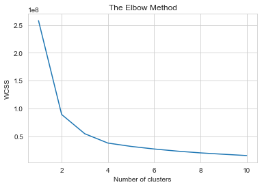

```python
# Using the elbow method to find the optimal number of clusters

wcss = []
for i in range(1, 11):
    kmeans = KMeans(n_clusters = i, init = 'k-means++', random_state = 42)
    kmeans.fit(X)
    wcss.append(kmeans.inertia_)
plt.plot(range(1, 11), wcss)
plt.title('The Elbow Method')
plt.xlabel('Number of clusters')
plt.ylabel('WCSS')
plt.show()
```

**We can select the optimum no of clusters to be 4 from the above graph.**

```python
# Fitting K-Means to the dataset
kmeans = KMeans(n_clusters = 4, init = 'k-means++', random_state = 42)
y_kmeans = kmeans.fit_predict(X)
```

```python
y_kmeans
```

```
array([0, 2, 3, ..., 1, 0, 0])
```

```python
X = np.array(X)
```

```python
X[y_kmeans == 3, 0]
```

```
array([1874, 1876, 1876, ..., 2019, 2019, 2019])
```

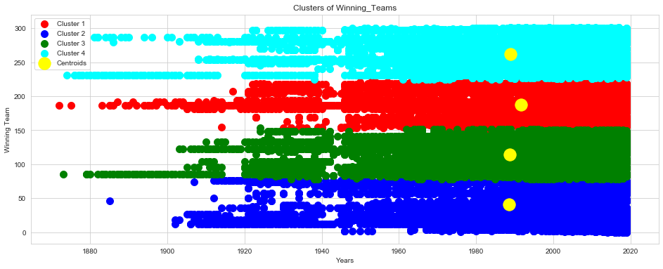

```python
# Visualising the clusters
plt.figure(1,figsize=(16,6))
plt.scatter(X[y_kmeans == 0, 0], X[y_kmeans == 0, 1], s = 100, c = 'red', label = 'Cluster 1')
plt.scatter(X[y_kmeans == 1, 0], X[y_kmeans == 1, 1], s = 100, c = 'blue', label = 'Cluster 2')
plt.scatter(X[y_kmeans == 2, 0], X[y_kmeans == 2, 1], s = 100, c = 'green', label = 'Cluster 3')
plt.scatter(X[y_kmeans == 3, 0], X[y_kmeans == 3, 1], s = 100, c = 'cyan', label = 'Cluster 4')
plt.scatter(kmeans.cluster_centers_[:, 0], kmeans.cluster_centers_[:, 1], s = 300, c = 'yellow', label = 'Centroids')
plt.title('Clusters of Winning_Teams')
plt.xlabel('Years')
plt.ylabel('Winning Team')
plt.legend()
plt.show()
```

## Analysing a second cluster

```python
Y = df.loc[:,['tournament_enc','winning_team_enc']]
```

```python
Y
```

|  | tournament_enc | winning_team_enc |
| --- | --- | --- |
| 0 | 54 | 187 |
| 1 | 54 | 85 |
| 2 | 54 | 231 |
| 3 | 54 | 187 |
| 4 | 54 | 231 |
| ... | ... | ... |
| 40834 | 83 | 5 |
| 40835 | 83 | 187 |
| 40836 | 7 | 4 |
| 40837 | 61 | 188 |
| 40838 | 83 | 187 |

40839 rows × 2 columns

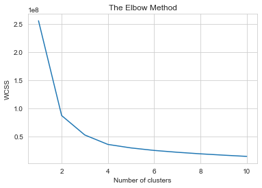

```python
# Using the elbow method to find the optimal number of clusters

wcss = []
for i in range(1, 11):
    kmeans = KMeans(n_clusters = i, init = 'k-means++', random_state = 42)
    kmeans.fit(Y)
    wcss.append(kmeans.inertia_)
plt.plot(range(1, 11), wcss)
plt.title('The Elbow Method')
plt.xlabel('Number of clusters')
plt.ylabel('WCSS')
plt.show()
```

```python
# Fitting K-Means to the dataset
kmeans = KMeans(n_clusters = 4, init = 'k-means++', random_state = 42)
y_kmeans_pred = kmeans.fit_predict(Y)
```

```python
Y = np.array(Y)
```

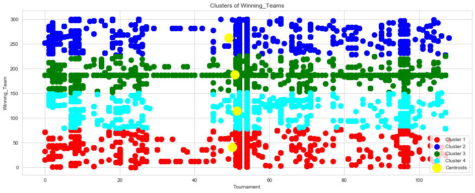

```python
# Visualising the clusters
plt.figure(1,figsize=(16,6))
plt.scatter(Y[y_kmeans_pred == 0, 0], Y[y_kmeans_pred == 0, 1], s = 100, c = 'red', label = 'Cluster 1')
plt.scatter(Y[y_kmeans_pred == 1, 0], Y[y_kmeans_pred == 1, 1], s = 100, c = 'blue', label = 'Cluster 2')
plt.scatter(Y[y_kmeans_pred == 2, 0], Y[y_kmeans_pred == 2, 1], s = 100, c = 'green', label = 'Cluster 3')
plt.scatter(Y[y_kmeans_pred == 3, 0], Y[y_kmeans_pred == 3, 1], s = 100, c = 'cyan', label = 'Cluster 4')
plt.scatter(kmeans.cluster_centers_[:, 0], kmeans.cluster_centers_[:, 1], s = 300, c = 'yellow', label = 'Centroids')
plt.title('Clusters of Winning_Teams')
plt.xlabel('Tournament')
plt.ylabel('Winning_Team')
plt.legend()
plt.show()
```